# Aula 8 - Introdução à Econometria

Autor

João Ricardo F. de Lima

Data de Publicação

29 de setembro de 2026

# Quebra de Pressupostos do Modelo Clássico de Regressão Linear

## Multicolinearidade

Uma das premissas do Modelo Clássico de Regressão Linear é que não existe **multicolinearidade** entre as variáveis explicativas no modelo de regressão a ser estimado. Originalmente, **multicolinearidade** designava a existência de uma “relação perfeita” entre algumas ou todas as variáveis explicativas de um modelo de regressão. Atualmente, também é considerado o caso de **multicolinearidade** menos que perfeita.

### Por que a multicolinearidade é um problema? Uma intuição geométrica

Antes de entrar nos aspectos técnicos, vale entender **por que** isso importa. Gujarati & Porter (2009) usam diagramas de Venn para dar essa intuição: pense em cada círculo como representando a variância de uma variável, e nas áreas de sobreposição como a variância que duas (ou mais) variáveis têm em comum.

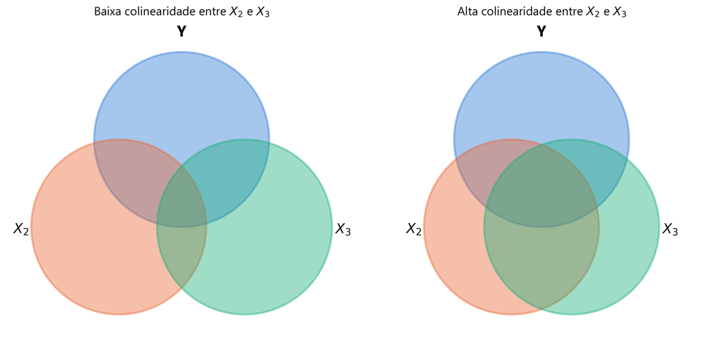

Intuição geométrica da multicolinearidade

Fonte: elaboração própria, com base em Gujarati & Porter (2009)

O MQO só consegue estimar o efeito **líquido** (isolado) de $X_2$ sobre $Y$ a partir da área em que $X_2$ e $Y$ se sobrepõem **sem** envolver $X_3$ — ou seja, a variação em $Y$ que só $X_2$ ajuda a explicar, mantendo $X_3$ constante. O mesmo vale para o efeito líquido de $X_3$.

- No painel da **esquerda** (baixa colinearidade entre $X_2$ e $X_3$), essas áreas exclusivas são grandes: o modelo consegue atribuir, com boa precisão, “quanto” de $Y$ vem de $X_2$ e “quanto” vem de $X_3$.
- No painel da **direita** (alta colinearidade), $X_2$ e $X_3$ passam a se sobrepor fortemente entre si. A área em que os três círculos se cruzam ($Y \cap X_2 \cap X_3$) cresce, mas essa área é **ambígua**: o modelo não sabe se deve atribuir essa parte de $Y$ a $X_2$ ou a $X_3$, já que as duas variáveis se movem quase sempre juntas na amostra. Sobra pouca área exclusiva para cada uma, mesmo que a área total explicada de $Y$ (soma de todas as sobreposições) continue grande.

É exatamente essa perda de área exclusiva que se traduz, algebricamente, em variância inflada dos estimadores $\hat\beta$ (erro-padrão grande, intervalo de confiança largo, estatística t baixa) — mesmo com $R^2$ alto, como será visto na próxima seção. No caso extremo de colinearidade perfeita, os círculos de $X_2$ e $X_3$ se sobrepõem por completo, não sobra nenhuma área exclusiva, e o efeito individual de cada variável deixa de ser identificável — é o mesmo resultado que aparece adiante, de forma algébrica, quando $|\mathbf{X'X}|=0$.

```r
x1 <- c(10,15,18,24,30)
x2 <- c(50,75,90,120,150)
x3 <- c(52,75,97,129,152)
x <- cbind(x1,x2,x3)
cor(x)
```

```
          x1        x2        x3
x1 1.0000000 1.0000000 0.9958817
x2 1.0000000 1.0000000 0.9958817
x3 0.9958817 0.9958817 1.0000000
```

A correlação entre $X_1$ e $X_2$ é igual a 1. A correlação entre $X_1$ e $X_3$ é 0,995. No primeiro caso se tem perfeita correlação. Se fosse estimar um modelo de regressão com estas duas variáveis explicativas, $X_1$ e $X_2$, teriamos um caso de multicolinearidade perfeita e os betas não seriam estimáveis. A demonstração é dada em Gujarati & Porter (2009).

A título de exemplo, se pode observar com a matrix X abaixo:

$$\mathbf{X}=\left[\begin{array}{ccc}
1 & 10 & 50 \\
1 & 15 & 75 \\
1 & 18 & 90 \\
\end{array} \right]; \mathbf{X'X}=\left[\begin{array}{ccc}
3 & 43 & 215 \\
43 & 649 & 3245 \\
215 & 3245 & 16225 \\
\end{array} \right]$$

sendo o determinante desta matriz igual a zero $|\mathbf{X'X}|=0$, não se consegue inverter a matriz e, então, não se consegue encontrar os betas em $(\mathbf{X'X})^{-1}\mathbf{X'Y}$.

```r
x1 <- c(1,1,1)
x2 <- c(10,15,18)
x3 <- c(50,75,90)
x <- cbind(x1,x2,x3)

x <- as.matrix(x)

# X'X
m1 <- t(x) %*% x

m1
```

```
    x1   x2    x3
x1   3   43   215
x2  43  649  3245
x3 215 3245 16225
```

```r
# Determinante

det(m1)
```

```
[1] 0
```

A colinearidade se refere às relações lineares entre as variáveis explicativas. Não inclui relações não lineares, como por exemplo:

$$Y_i=\beta_0+\beta_1X+\beta_2X^2+\beta_3X^3$$

em que Y é o custo total e X a quantidade produzida.

Se o modelo conter regressores perfeitamente correlacionados, o R produzirá um aviso na primeira linha da seção de coeficientes da saída (1 não definido por causa das singularidades) e ignorará o(s) regressor(es) que é(são) assumido(s) como uma combinação linear do(s) outro(s).

## Consequências da multicolinearidade

Os estimadores de MQO continuam não viesados e eficientes (possuem variância mínima).

Contudo, esta variância é “inflada”, ou seja, muito grande.

Se o erro padrão é grande, os intervalos de confiança também serão mais amplos:

$$IC=\hat\beta\pm t_{\alpha/2}ep(\hat \beta)$$

Como o erro padrão é grande, normalmente os betas são não significativos, ou seja, iguais a zero.

O sintoma clássico da multicolinearidade é justamente essa combinação: $R^2$ (e a estatística F do modelo) alto e significativo, mostrando que as variáveis explicativas em conjunto explicam bem Y, mas com poucos ou nenhum coeficiente individualmente significativo — porque a variância de cada $\hat\beta$ está inflada.

Os estimadores de MQO e os erros-padrões podem ser sensíveis às pequenas mudanças nos dados.

Em resumo, os resultados encontrados se tornam duvidosos quando se regride com regressores colineares.

## Como detectar a multicolinearidade?

Na regressão, encontrar muitos betas estimados não significativos e o $R^2$ muito alto.

Altos valores de correlações entre pares de regressores;

Calcular regressões auxiliares. Dado o modelo:

$$Y_i=\beta_0+\beta_1X_1+\beta_2X_2+\beta_3X_3+u$$

calcular o $R^2$ e chamar de $R^2$ geral. Depois regredir:

$$X_1=\beta_0+\beta_2X_2+\beta_3X_3+u$$

$$X_2=\beta_0+\beta_1X_1+\beta_3X_3+u$$

$$X_3=\beta_0+\beta_1X_1+\beta_2X_2+u$$

calcular em cada regressão auxiliar os $R^2$: a) $R^2_{x_1.x_2x_3}$; b) $R^2_{x_2.x_1x_3}$; c) $R^2_{x_3.x_1x_2}$

comparar cada um com o $R^2$ geral. Pela *Regra Prática de Klein*, a multicolinearidade pode ser um problema sério se o $R^2$ obtido em **qualquer uma** das regressões auxiliares, isoladamente, for maior do que o $R^2$ geral — não é necessário que isso ocorra simultaneamente em todas elas.

**Fator de Inflação de Variância** - Considerando uma regressão múltipla com duas variáveis explicativas, as variâncias dos coeficientes de inclinação são dadas por:

$$Var(\hat\beta_2)=\frac{\sigma^2}{\sum x^2_2(1-r^2_{23})}$$

$$Var(\hat\beta_3)=\frac{\sigma^2}{\sum x^2_3(1-r^2_{23})}$$

em que $\sigma^2$ é a variância do termo de erro e $r^2_{23}$ é o coeficiente de correlação entre $x_2$ e $x_3$.

se considerarmos a razão $\frac{1}{1-r^2_{23}}$, esta mensura o grau na qual a variância do estimador de MQO é inflado devido a colinearidade. Este fator é conhecido como **FIV** (Fator de Inflação de Variância).

Se o FIV for maior do que 10 diz-se que esta variável é altamente colinear; Com mais de 2 variáveis, o quadrado do coeficiente de correlação pode ser obtido do $R^2$ das regressões auxiliares.

**Tolerância (TOL)** - é simplesmente o inverso do FIV:

$$TOL=\frac{1}{FIV}=(1-r^2_{23})$$

Enquanto o FIV mede o quanto a variância do $\hat\beta$ está inflada pela colinearidade, a TOL mede a proporção da variância de $X_2$ (ou $X_3$) que **não** é explicada pelas demais variáveis explicativas — quanto mais próxima de zero, maior a colinearidade.

Como o limite prático do FIV é 10, o limite correspondente da TOL é o seu inverso: $TOL<0,10$ também indica multicolinearidade severa. Ou seja, FIV e TOL são a mesma informação vista de ângulos opostos — não é necessário calcular os dois, mas é comum que os softwares estatísticos reportem ambos.

## Medidas corretivas para Multicolinearidade

1. Aumentar o tamanho da amostra;
2. Exclusão de variáveis, desde que não cause viés de especificação ou omissão de variável relevante;
3. Combinar as variáveis colineares em um único índice ou variável composta, quando fizer sentido teórico (por exemplo, um indicador que resuma duas variáveis muito correlacionadas);
4. Buscar informação extra-amostral ou *a priori* (por exemplo, um valor de elasticidade já conhecido de outro estudo) para fixar um dos parâmetros e reduzir o número de coeficientes a estimar livremente;
5. Não fazer nada: se o objetivo do modelo é apenas prever Y (e não interpretar individualmente cada $\hat\beta$), a multicolinearidade não compromete a qualidade da previsão, desde que o padrão de correlação entre os regressores se mantenha fora da amostra.

## Multicolinearidade: Exemplo no R

### Estimação do Modelo

```r
#Direcionando o R para o Diretorio a ser trabalhado
#setwd('/Users/jricardofl/Dropbox/tempecon/facape/econometria1')

#Inicio do Script
#Pacotes a serem utilizados
library(wooldridge)
library(car)
library(corrplot)
library(HH)

data("wage2")

sal <- na.omit(wage2)
attach(sal)

#Regressao Multipla
#tenure= anos no emprego atual
regressao1 <- lm(log(wage) ~ educ + exper + tenure)
summary(regressao1)
```

```
Call:
lm(formula = log(wage) ~ educ + exper + tenure)

Residuals:
     Min       1Q   Median       3Q      Max
-1.85742 -0.23602  0.01713  0.24604  1.30811

Coefficients:
            Estimate Std. Error t value Pr(>|t|)
(Intercept) 5.502235   0.128251  42.902  < 2e-16 ***
educ        0.075716   0.007447  10.167  < 2e-16 ***
exper       0.017993   0.004076   4.415 1.18e-05 ***
tenure      0.009863   0.003066   3.217  0.00136 **
---
Signif. codes:  0 '***' 0.001 '**' 0.01 '*' 0.05 '.' 0.1 ' ' 1

Residual standard error: 0.379 on 659 degrees of freedom
Multiple R-squared:  0.1585,    Adjusted R-squared:  0.1547
F-statistic: 41.39 on 3 and 659 DF,  p-value: < 2.2e-16
```

### Início da análise: verificação da correlação

```r
#Matriz de Correlacoes das variaveis explicativas
x <- sal[, c(5:7)]
cor(x)
```

```
              educ      exper      tenure
educ    1.00000000 -0.4508258 -0.03012161
exper  -0.45082581  1.0000000  0.29005009
tenure -0.03012161  0.2900501  1.00000000
```

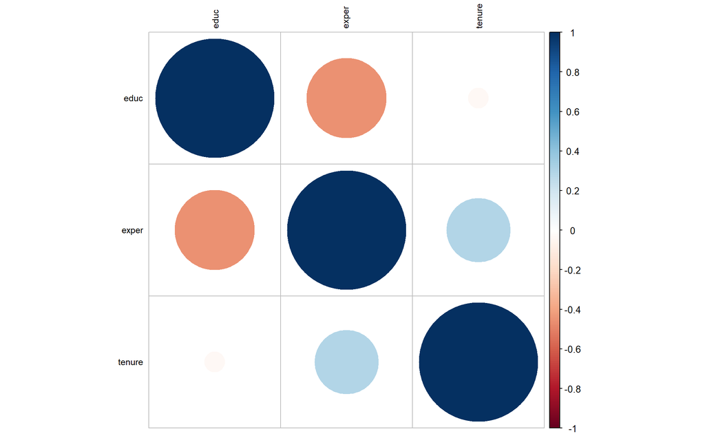

```r
corrplot(cor(x), order="hclust", tl.col="black", tl.cex = .75)
```

### Estimação das regressões auxiliares

```r
#Regressoes Auxiliares

aux1 <- lm(educ ~ exper + tenure)
summary(aux1)
```

```
Call:
lm(formula = educ ~ exper + tenure)

Residuals:
    Min      1Q  Median      3Q     Max
-5.0084 -1.4863 -0.3875  1.5734  5.1828

Coefficients:
            Estimate Std. Error t value Pr(>|t|)
(Intercept) 16.21282    0.22610  71.708   <2e-16 ***
exper       -0.25293    0.01889 -13.389   <2e-16 ***
tenure       0.04850    0.01591   3.048   0.0024 **
---
Signif. codes:  0 '***' 0.001 '**' 0.01 '*' 0.05 '.' 0.1 ' ' 1

Residual standard error: 1.981 on 660 degrees of freedom
Multiple R-squared:  0.2143,    Adjusted R-squared:  0.2119
F-statistic: 90.01 on 2 and 660 DF,  p-value: < 2.2e-16
```

```r
aux2 <- lm(exper~ educ + tenure)
summary(aux2)
```

```
Call:
lm(formula = exper ~ educ + tenure)

Residuals:
     Min       1Q   Median       3Q      Max
-11.2109  -2.2600   0.0697   2.5506   9.8563

Coefficients:
            Estimate Std. Error t value Pr(>|t|)
(Intercept) 21.26670    0.90280  23.556  < 2e-16 ***
educ        -0.84445    0.06307 -13.389  < 2e-16 ***
tenure       0.23308    0.02784   8.373 3.37e-16 ***
---
Signif. codes:  0 '***' 0.001 '**' 0.01 '*' 0.05 '.' 0.1 ' ' 1

Residual standard error: 3.619 on 660 degrees of freedom
Multiple R-squared:  0.2797,    Adjusted R-squared:  0.2776
F-statistic: 128.2 on 2 and 660 DF,  p-value: < 2.2e-16
```

```r
aux3 <- lm(tenure ~ educ + exper)
summary(aux3)
```

```
Call:
lm(formula = tenure ~ educ + exper)

Residuals:
   Min     1Q Median     3Q    Max
-9.693 -3.985 -0.161  3.671 13.191

Coefficients:
            Estimate Std. Error t value Pr(>|t|)
(Intercept)  -1.3929     1.6275  -0.856   0.3924
educ          0.2862     0.0939   3.048   0.0024 **
exper         0.4120     0.0492   8.373 3.37e-16 ***
---
Signif. codes:  0 '***' 0.001 '**' 0.01 '*' 0.05 '.' 0.1 ' ' 1

Residual standard error: 4.812 on 660 degrees of freedom
Multiple R-squared:  0.09684,   Adjusted R-squared:  0.0941
F-statistic: 35.38 on 2 and 660 DF,  p-value: 2.524e-15
```

### Cálculo do Fator de Inflação da Variância

```r
#Fator de Inflacao da Variancia (FIV)
vif(lm(log(wage) ~ educ + exper + tenure))
```

```
    educ    exper   tenure
1.272755 1.388405 1.107225
```

```r
detach(sal)
```

### Uso do pacote {performance}

```r
pacman::p_load(
"performance",
"lme4",
"see",
"qqplotr"
)

model_performance(regressao1)
```

|  | AIC | AICc | BIC | R2 | R2_adjusted | RMSE | Sigma |
| --- | --- | --- | --- | --- | --- | --- | --- |
| 1 | 9636.677 | 9636.768 | 9659.161 | 0.1585469 | 0.1547164 | 0.3778348 | 0.3789797 |

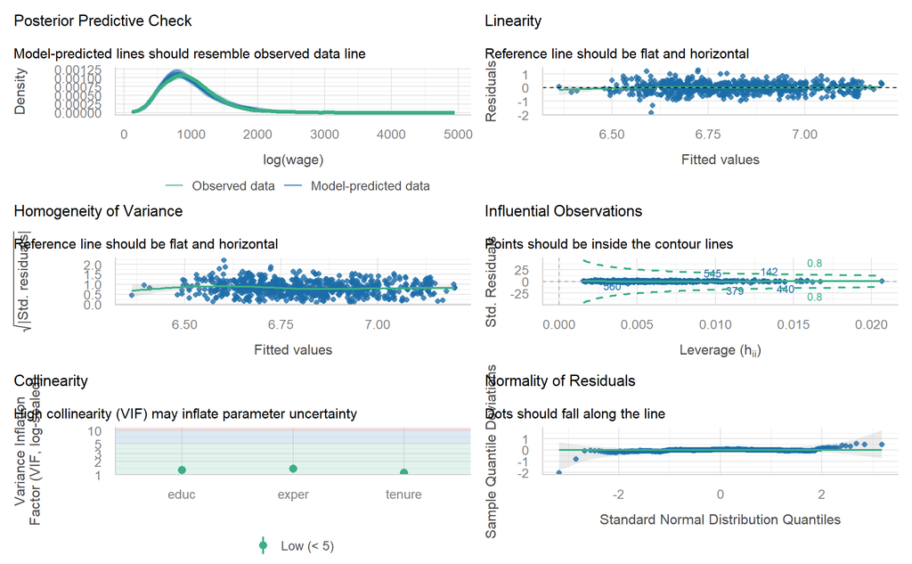

```r
check_model(regressao1)
```

## Multicolinearidade: Exemplo no Python

```python
import wooldridge
import pandas as pd
import numpy as np
import matplotlib.pyplot as plt
import seaborn as sns
import statsmodels.formula.api as smf
import statsmodels.api as sm
from statsmodels.stats.outliers_influence import variance_inflation_factor
import scipy.stats as stats

#Carregar dados no computador
wage2 = wooldridge.data('wage2')

sal = wage2.dropna()

#Estimando a 1 Regressão Multipla Modelo Irrestrito
reg1 = smf.ols('np.log(wage) ~ educ + exper + tenure', data=sal)
#Output de Resultado
result1 = reg1.fit()
print(result1.summary())
```

```
                            OLS Regression Results
==============================================================================
Dep. Variable:           np.log(wage)   R-squared:                       0.159
Model:                            OLS   Adj. R-squared:                  0.155
Method:                 Least Squares   F-statistic:                     41.39
Date:                ter, 29 set 2026   Prob (F-statistic):           1.63e-24
Time:                        10:20:58   Log-Likelihood:                -295.46
No. Observations:                 663   AIC:                             598.9
Df Residuals:                     659   BIC:                             616.9
Df Model:                           3
Covariance Type:            nonrobust
==============================================================================
                 coef    std err          t      P>|t|      [0.025      0.975]
------------------------------------------------------------------------------
Intercept      5.5022      0.128     42.902      0.000       5.250       5.754
educ           0.0757      0.007     10.167      0.000       0.061       0.090
exper          0.0180      0.004      4.415      0.000       0.010       0.026
tenure         0.0099      0.003      3.217      0.001       0.004       0.016
==============================================================================
Omnibus:                       16.700   Durbin-Watson:                   1.850
Prob(Omnibus):                  0.000   Jarque-Bera (JB):               27.658
Skew:                          -0.175   Prob(JB):                     9.86e-07
Kurtosis:                       3.937   Cond. No.                         171.
==============================================================================

Notes:
[1] Standard Errors assume that the covariance matrix of the errors is correctly specified.
```

```python
# Cria um subgrupo
sal2 = sal[["educ", "exper", "tenure"]]

# Calcula a matriz de correlações
correlation_matrix = sal2.corr()

# Mostra a matriz de correlações
print(correlation_matrix)
```

```
            educ     exper    tenure
educ    1.000000 -0.450826 -0.030122
exper  -0.450826  1.000000  0.290050
tenure -0.030122  0.290050  1.000000
```

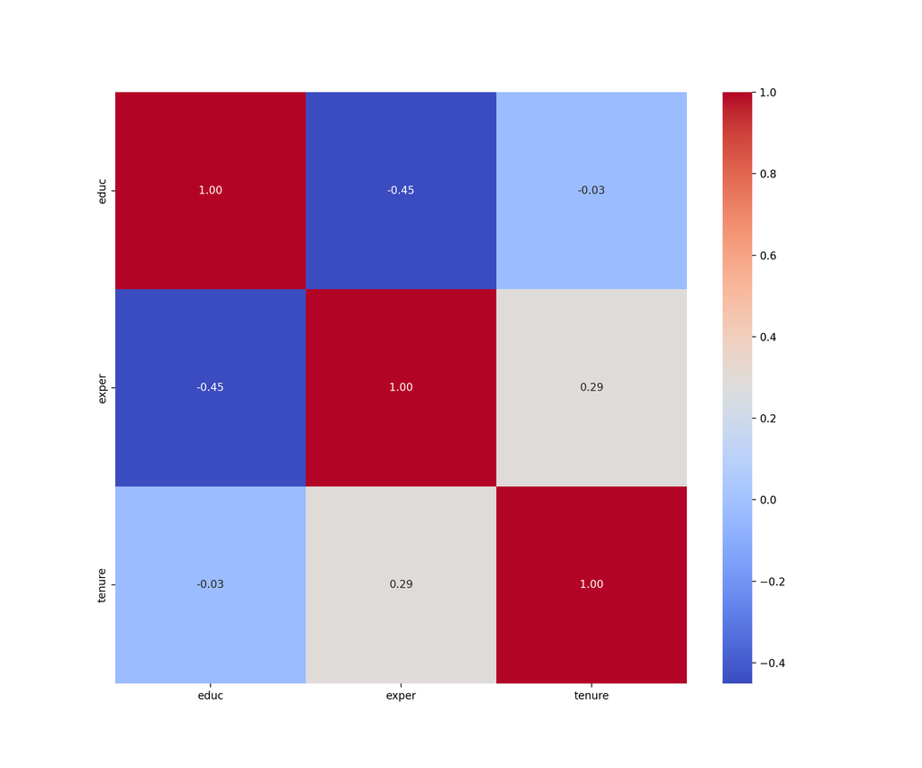

```python
# Define o tamanho do gráfico
plt.figure(figsize=(12, 10))

# Cria um heatmap (representaçao por cores) da matriz de correlações
sns.heatmap(correlation_matrix, annot=True, cmap='coolwarm', fmt='.2f')

# Mostra o Gráfico das Correlações
plt.show()
```

```python
#Estimação das matrizes auxiliares

#Estimando as regressoes auxiliares
aux1 = smf.ols('educ ~ exper + tenure', data=sal)
#Output de Resultado
result1 = aux1.fit()
print(result1.summary())
```

```
                            OLS Regression Results
==============================================================================
Dep. Variable:                   educ   R-squared:                       0.214
Model:                            OLS   Adj. R-squared:                  0.212
Method:                 Least Squares   F-statistic:                     90.01
Date:                ter, 29 set 2026   Prob (F-statistic):           2.72e-35
Time:                        10:20:58   Log-Likelihood:                -1392.4
No. Observations:                 663   AIC:                             2791.
Df Residuals:                     660   BIC:                             2804.
Df Model:                           2
Covariance Type:            nonrobust
==============================================================================
                 coef    std err          t      P>|t|      [0.025      0.975]
------------------------------------------------------------------------------
Intercept     16.2128      0.226     71.708      0.000      15.769      16.657
exper         -0.2529      0.019    -13.389      0.000      -0.290      -0.216
tenure         0.0485      0.016      3.048      0.002       0.017       0.080
==============================================================================
Omnibus:                       30.955   Durbin-Watson:                   1.906
Prob(Omnibus):                  0.000   Jarque-Bera (JB):               21.956
Skew:                           0.335   Prob(JB):                     1.71e-05
Kurtosis:                       2.412   Cond. No.                         42.6
==============================================================================

Notes:
[1] Standard Errors assume that the covariance matrix of the errors is correctly specified.
```

```python
aux2 = smf.ols('exper ~ educ + tenure', data=sal)
#Output de Resultado
result2 = aux2.fit()
print(result2.summary())
```

```
                            OLS Regression Results
==============================================================================
Dep. Variable:                  exper   R-squared:                       0.280
Model:                            OLS   Adj. R-squared:                  0.278
Method:                 Least Squares   F-statistic:                     128.2
Date:                ter, 29 set 2026   Prob (F-statistic):           9.32e-48
Time:                        10:20:58   Log-Likelihood:                -1792.1
No. Observations:                 663   AIC:                             3590.
Df Residuals:                     660   BIC:                             3604.
Df Model:                           2
Covariance Type:            nonrobust
==============================================================================
                 coef    std err          t      P>|t|      [0.025      0.975]
------------------------------------------------------------------------------
Intercept     21.2667      0.903     23.556      0.000      19.494      23.039
educ          -0.8444      0.063    -13.389      0.000      -0.968      -0.721
tenure         0.2331      0.028      8.373      0.000       0.178       0.288
==============================================================================
Omnibus:                        7.309   Durbin-Watson:                   2.068
Prob(Omnibus):                  0.026   Jarque-Bera (JB):                7.268
Skew:                          -0.255   Prob(JB):                       0.0264
Kurtosis:                       3.058   Cond. No.                         102.
==============================================================================

Notes:
[1] Standard Errors assume that the covariance matrix of the errors is correctly specified.
```

```python
aux3 = smf.ols('tenure ~ educ + exper', data=sal)
#Output de Resultado
result3 = aux3.fit()
print(result3.summary())
```

```
                            OLS Regression Results
==============================================================================
Dep. Variable:                 tenure   R-squared:                       0.097
Model:                            OLS   Adj. R-squared:                  0.094
Method:                 Least Squares   F-statistic:                     35.38
Date:                ter, 29 set 2026   Prob (F-statistic):           2.52e-15
Time:                        10:20:58   Log-Likelihood:                -1980.9
No. Observations:                 663   AIC:                             3968.
Df Residuals:                     660   BIC:                             3981.
Df Model:                           2
Covariance Type:            nonrobust
==============================================================================
                 coef    std err          t      P>|t|      [0.025      0.975]
------------------------------------------------------------------------------
Intercept     -1.3929      1.628     -0.856      0.392      -4.589       1.803
educ           0.2862      0.094      3.048      0.002       0.102       0.471
exper          0.4120      0.049      8.373      0.000       0.315       0.509
==============================================================================
Omnibus:                       62.169   Durbin-Watson:                   2.119
Prob(Omnibus):                  0.000   Jarque-Bera (JB):               25.300
Skew:                           0.255   Prob(JB):                     3.21e-06
Kurtosis:                       2.190   Cond. No.                         157.
==============================================================================

Notes:
[1] Standard Errors assume that the covariance matrix of the errors is correctly specified.
```

```python
#Fator de Inflacao da Variancia (FIV)

# Adiciona o intercepto
X = sal2 #sal2 foi criada para as regressoes auxiliares
X = sm.add_constant(X)

# Calculate VIF for each feature
vif = pd.DataFrame()
vif["Variable"] = X.columns
vif["VIF"] = [variance_inflation_factor(X.values, i) for i in range(X.shape[1])]

# Display the VIF
print(vif)
```

```
  Variable        VIF
0    const  75.928713
1     educ   1.272755
2    exper   1.388405
3   tenure   1.107225
```

```python
# Calcula o VIF usando a matriz de correlações
#corr_matrix = X.corr()

#vif = pd.DataFrame()
#vif["Variable"] = corr_matrix.index
#vif["VIF"] = np.diag(np.linalg.inv(corr_matrix.values))

# Print VIF values
#print(vif)
```